# Keine Panik auf der Titanic

Marc Schwering

# 1 Introduction

This is my first Kaggle script. Since, the Titanic set is recommended for beginners I will try this one. I will just go through data quality, feature extraction, modelling, and prediction like I would always do. However, feature extraction is often not really straight forward, so maybe I go back and forth a little bit.

I have looked into some scripts for the Titanic set. A lot of people use a random forest as first choice. However, I have seen nobody using a plain old linear discriminant analysis. This is usually one of my first choices, so I will use it here.

```r
library(data.table) # database-like tables
library(vcd) # actually just for mosaic plot
library(ggplot2) # general plots
library(sda) # shrinkage discriminant analysis
```

Let’s load the data. I belong to the `data.table` people here.

```r
test <- read.csv("../input/test.csv")
train <- read.csv("../input/train.csv")
test <- data.table(test)
train <- data.table(train)
str(train)
```

```
## Classes 'data.table' and 'data.frame':   891 obs. of  12 variables:
##  $ PassengerId: int  1 2 3 4 5 6 7 8 9 10 ...
##  $ Survived   : int  0 1 1 1 0 0 0 0 1 1 ...
##  $ Pclass     : int  3 1 3 1 3 3 1 3 3 2 ...
##  $ Name       : Factor w/ 891 levels "Abbing, Mr. Anthony",..: 109 191 358 277 16 559 520 629 416 581 ...
##  $ Sex        : Factor w/ 2 levels "female","male": 2 1 1 1 2 2 2 2 1 1 ...
##  $ Age        : num  22 38 26 35 35 NA 54 2 27 14 ...
##  $ SibSp      : int  1 1 0 1 0 0 0 3 0 1 ...
##  $ Parch      : int  0 0 0 0 0 0 0 1 2 0 ...
##  $ Ticket     : Factor w/ 681 levels "110152","110413",..: 525 596 662 50 473 276 86 396 345 133 ...
##  $ Fare       : num  7.25 71.28 7.92 53.1 8.05 ...
##  $ Cabin      : Factor w/ 148 levels "","A10","A14",..: 1 83 1 57 1 1 131 1 1 1 ...
##  $ Embarked   : Factor w/ 4 levels "","C","Q","S": 4 2 4 4 4 3 4 4 4 2 ...
##  - attr(*, ".internal.selfref")=<externalptr>
```

```r
str(test)
```

```
## Classes 'data.table' and 'data.frame':   418 obs. of  11 variables:
##  $ PassengerId: int  892 893 894 895 896 897 898 899 900 901 ...
##  $ Pclass     : int  3 3 2 3 3 3 3 2 3 3 ...
##  $ Name       : Factor w/ 418 levels "Abbott, Master. Eugene Joseph",..: 210 409 273 414 182 370 85 58 5 104 ...
##  $ Sex        : Factor w/ 2 levels "female","male": 2 1 2 2 1 2 1 2 1 2 ...
##  $ Age        : num  34.5 47 62 27 22 14 30 26 18 21 ...
##  $ SibSp      : int  0 1 0 0 1 0 0 1 0 2 ...
##  $ Parch      : int  0 0 0 0 1 0 0 1 0 0 ...
##  $ Ticket     : Factor w/ 363 levels "110469","110489",..: 153 222 74 148 139 262 159 85 101 268 ...
##  $ Fare       : num  7.83 7 9.69 8.66 12.29 ...
##  $ Cabin      : Factor w/ 77 levels "","A11","A18",..: 1 1 1 1 1 1 1 1 1 1 ...
##  $ Embarked   : Factor w/ 3 levels "C","Q","S": 2 3 2 3 3 3 2 3 1 3 ...
##  - attr(*, ".internal.selfref")=<externalptr>
```

Some of the factors should be `character`, so…

```r
train[, Name := as.character(Name)]
train[, Ticket := as.character(Ticket)]
train[, Cabin := as.character(Cabin)]
train[, Survived := as.factor(Survived)]
train[, Survived := as.factor(Pclass)]
test[, Name := as.character(Name)]
test[, Ticket := as.character(Ticket)]
test[, Cabin := as.character(Cabin)]
test[, Survived := as.factor(Pclass)]
```

# 2 Data Quality

Here, I basically go through the current features and see if there is something important like missing values or weird values. I don’t really look at distributions and correlations yet.

## 2.1 PasserngerId

This is just a sanity check.

```r
cat(sprintf(
  "train has %d rows and %d unique passenger IDs\n",
  nrow(train), length(unique(train$PassengerId))
))
```

train has 891 rows and 891 unique passenger IDs

```r
cat(sprintf(
  "test has %d rows and %d unique passenger IDs\n",
  nrow(test), length(unique(test$PassengerId))
))
```

test has 418 rows and 418 unique passenger IDs

## 2.2 Survived

This is a sanity check for the training labels.

```r
table(train$Survived)
```

```
##
##   1   2   3
## 216 184 491
```

## 2.3 Pclass

```r
table(train$Pclass)
```

```
##
##   1   2   3
## 216 184 491
```

```r
table(test$Pclass)
```

```
##
##   1   2   3
## 107  93 218
```

## 2.4 Name

This will be an interesting feature. However, here I just check if it contains empty values or weirdly short names.

```r
head(train$Name)
```

```
## [1] "Braund, Mr. Owen Harris"
## [2] "Cumings, Mrs. John Bradley (Florence Briggs Thayer)"
## [3] "Heikkinen, Miss. Laina"
## [4] "Futrelle, Mrs. Jacques Heath (Lily May Peel)"
## [5] "Allen, Mr. William Henry"
## [6] "Moran, Mr. James"
```

```r
head(test$Name)
```

```
## [1] "Kelly, Mr. James"
## [2] "Wilkes, Mrs. James (Ellen Needs)"
## [3] "Myles, Mr. Thomas Francis"
## [4] "Wirz, Mr. Albert"
## [5] "Hirvonen, Mrs. Alexander (Helga E Lindqvist)"
## [6] "Svensson, Mr. Johan Cervin"
```

```r
any(nchar(train$Name) < 3)
```

```
## [1] FALSE
```

```r
any(nchar(test$Name) < 3)
```

```
## [1] FALSE
```

## 2.5 Sex

```r
table(train$Sex)
```

```
##
## female   male
##    314    577
```

```r
table(test$Sex)
```

```
##
## female   male
##    152    266
```

## 2.6 Age

```r
summary(train$Age)
```

```
##    Min. 1st Qu.  Median    Mean 3rd Qu.    Max.    NA's
##    0.42   20.12   28.00   29.70   38.00   80.00     177
```

```r
summary(test$Age)
```

```
##    Min. 1st Qu.  Median    Mean 3rd Qu.    Max.    NA's
##    0.17   21.00   27.00   30.27   39.00   76.00      86
```

Ouh, there are many NAs. We will have to think of something for these. Age range seems reasonable: from 2 months to 80 years old.

## 2.7 SibSp and Parch

```r
table(train$SibSp)
```

```
##
##   0   1   2   3   4   5   8
## 608 209  28  16  18   5   7
```

```r
table(test$SibSp)
```

```
##
##   0   1   2   3   4   5   8
## 283 110  14   4   4   1   2
```

```r
table(train$Parch)
```

```
##
##   0   1   2   3   4   5   6
## 678 118  80   5   4   5   1
```

```r
table(test$Parch)
```

```
##
##   0   1   2   3   4   5   6   9
## 324  52  33   3   2   1   1   2
```

## 2.8 Ticket

There is probably a lot to extract here.

```r
head(train$Ticket)
```

```
## [1] "A/5 21171"        "PC 17599"         "STON/O2. 3101282"
## [4] "113803"           "373450"           "330877"
```

```r
head(test$Ticket)
```

```
## [1] "330911"  "363272"  "240276"  "315154"  "3101298" "7538"
```

```r
any(train$Ticket  == "")
```

```
## [1] FALSE
```

```r
any(test$Ticket == "")
```

```
## [1] FALSE
```

## 2.9 Fare

```r
summary(train$Fare)
```

```
##    Min. 1st Qu.  Median    Mean 3rd Qu.    Max.
##    0.00    7.91   14.45   32.20   31.00  512.30
```

```r
summary(test$Fare)
```

```
##    Min. 1st Qu.  Median    Mean 3rd Qu.    Max.    NA's
##   0.000   7.896  14.450  35.630  31.500 512.300       1
```

```r
test[is.na(Fare), ]
```

```
##    PassengerId Pclass               Name  Sex  Age SibSp Parch Ticket Fare
## 1:        1044      3 Storey, Mr. Thomas male 60.5     0     0   3701   NA
##    Cabin Embarked Survived
## 1:              S        3
```

There is one NA *Fare* in the test set. We keep this for now.

Also, in both *test* and *train* there are some weirdly high values of 512.3. What’s up with these?

```r
train[Fare > 512, ]
```

```
##    PassengerId Survived Pclass                               Name    Sex
## 1:         259        1      1                   Ward, Miss. Anna female
## 2:         680        1      1 Cardeza, Mr. Thomas Drake Martinez   male
## 3:         738        1      1             Lesurer, Mr. Gustave J   male
##    Age SibSp Parch   Ticket     Fare       Cabin Embarked
## 1:  35     0     0 PC 17755 512.3292                    C
## 2:  36     0     1 PC 17755 512.3292 B51 B53 B55        C
## 3:  35     0     0 PC 17755 512.3292        B101        C
```

```r
test[Fare > 512, ]
```

```
##    PassengerId Pclass
## 1:        1235      1
##                                                               Name    Sex
## 1: Cardeza, Mrs. James Warburton Martinez (Charlotte Wardle Drake) female
##    Age SibSp Parch   Ticket     Fare       Cabin Embarked Survived
## 1:  58     0     1 PC 17755 512.3292 B51 B53 B55        C        1
```

And there are free rides:

```r
train[Fare == 0, ]
```

```
##     PassengerId Survived Pclass                             Name  Sex Age
##  1:         180        3      3              Leonard, Mr. Lionel male  36
##  2:         264        1      1            Harrison, Mr. William male  40
##  3:         272        3      3     Tornquist, Mr. William Henry male  25
##  4:         278        2      2      Parkes, Mr. Francis "Frank" male  NA
##  5:         303        3      3  Johnson, Mr. William Cahoone Jr male  19
##  6:         414        2      2   Cunningham, Mr. Alfred Fleming male  NA
##  7:         467        2      2            Campbell, Mr. William male  NA
##  8:         482        2      2 Frost, Mr. Anthony Wood "Archie" male  NA
##  9:         598        3      3              Johnson, Mr. Alfred male  49
## 10:         634        1      1    Parr, Mr. William Henry Marsh male  NA
## 11:         675        2      2       Watson, Mr. Ennis Hastings male  NA
## 12:         733        2      2             Knight, Mr. Robert J male  NA
## 13:         807        1      1           Andrews, Mr. Thomas Jr male  39
## 14:         816        1      1                 Fry, Mr. Richard male  NA
```

[output cut: 17 more lines]

```r
test[Fare == 0, ]
```

```
##    PassengerId Pclass                                  Name  Sex Age SibSp
## 1:        1158      1 Chisholm, Mr. Roderick Robert Crispin male  NA     0
## 2:        1264      1               Ismay, Mr. Joseph Bruce male  49     0
##    Parch Ticket Fare       Cabin Embarked Survived
## 1:     0 112051    0                    S        1
## 2:     0 112058    0 B52 B54 B56        S        1
```

I wonder whether these were people that got a board last minute or so. That would explain why there are a lot of NAs for them.

## 2.10 Cabin

```r
head(train$Cabin)
```

```
## [1] ""     "C85"  ""     "C123" ""     ""
```

```r
head(test$Cabin)
```

```
## [1] "" "" "" "" "" ""
```

```r
table(train$Cabin == "")
```

```
##
## FALSE  TRUE
##   204   687
```

```r
table(test$Cabin == "")
```

```
##
## FALSE  TRUE
##    91   327
```

Ouh, this looks bad. Most are empty.

## 2.11 Embarked

```r
table(train$Embarked)
```

```
##
##       C   Q   S
##   2 168  77 644
```

```r
table(test$Embarked)
```

```
##
##   C   Q   S
## 102  46 270
```

```r
train[Embarked == "", ]
```

```
##    PassengerId Survived Pclass                                      Name
## 1:          62        1      1                       Icard, Miss. Amelie
## 2:         830        1      1 Stone, Mrs. George Nelson (Martha Evelyn)
##       Sex Age SibSp Parch Ticket Fare Cabin Embarked
## 1: female  38     0     0 113572   80   B28
## 2: female  62     0     0 113572   80   B28
```

In the training set there are 2 empty *Embarked* entries. Both survived, maybe they didn’t embark.

# 3 Feature Extraction

So now we know there are a few features which can still be extracted. I will do the feature extraction for the training set. But eventually I have to write a function that handles the feature extraction.

## 3.1 Names

I am starting with the *Names* column. Obviously one can extract *Surnames* and *Titles* from the names. This is something I have seen in `mrisdal`’s script.

### 3.1.1 Titles

This is from `mrisdal`’s script and I will do it the same way.

```r
train$Title <- gsub('(.*, )|(\\..*)', '', train$Name)
table(train$Title)
```

```
##
##         Capt          Col          Don           Dr     Jonkheer
##            1            2            1            7            1
##         Lady        Major       Master         Miss         Mlle
##            1            2           40          182            2
##          Mme           Mr          Mrs           Ms          Rev
##            1          517          125            1            6
##          Sir the Countess
##            1            1
```

```r
rare_title <- c('Dona', 'Lady', 'the Countess','Capt', 'Col', 'Don',
                'Dr', 'Major', 'Rev', 'Sir', 'Jonkheer')
train[Title == "Mlle", Title := "Miss"]
train[Title == "Ms", Title := "Miss"]
train[Title == "Mme", Title := "Mrs"]
train[Title %in% rare_title, Title := "Rare Title"]
```

```r
table(train$Title, train$Sex)
```

```
##
##              female male
##   Master          0   40
##   Miss          185    0
##   Mr              0  517
##   Mrs           126    0
##   Rare Title      3   20
```

### 3.1.2 Surnames

The surnames part is also form `mrisdal`.

```r
train$Surname <- vapply(
  train$Name,
  function(x) strsplit(x, "[,. ]")[[1]][1],
  character(1)
)
length(unique(train$Surname))
```

```
## [1] 661
```

```r
any(train$Surname == "")
```

```
## [1] FALSE
```

### 3.1.3 Identical Surnames

However, looking at the surnames I think for identifying families it might be handy to have the number of people with identical surnames aboard.

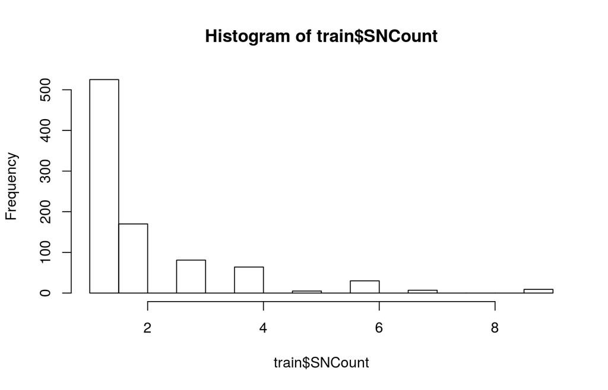

```r
counts <- table(train$Surname)
train$SNCount <- vapply(
  train$Surname,
  function(sn) counts[names(counts) == sn],
  integer(1)
)
hist(train$SNCount, breaks = 20)
```

## 3.2 Age

One important factor for survival is definitely the age. There is a natural step in the age feature at the age of 18. I will extract that as a binary feature.

```r
train$isChild <- as.integer(train$Age < 18)
table(train$isChild)
```

```
##
##   0   1
## 601 113
```

## 3.3 Families

Families probably stayed together. So knowning the families would be good for prediction. Using cabin information, Sibling/Spouses and Parent/Children, and the names one could try to link family members. For now I will just extract the general family size.

```r
train$FMembers <- train$SibSp + train$Parch + 1
```

## 3.4 Ticket

The tickets are not only numbers.

```r
txt <- gsub("[0-9\\. /]", "", train$Ticket)
(txt <- toupper(unique(txt)))
```

```
##  [1] "A"         "PC"        "STONO"     ""          "PP"
##  [6] "CA"        "SCPARIS"   "SCA"       "SP"        "SOC"
## [11] "WC"        "SOTONOQ"   "WEP"       "C"         "SCPARIS"
## [16] "SOP"       "FA"        "LINE"      "FCC"       "SWPP"
## [21] "SCOW"      "PPP"       "SC"        "SCAH"      "AS"
## [26] "SCAHBASLE" "SOPP"      "FC"        "SOTONO"    "CASOTON"
```

### 3.4.1 Ticket Text

This seems to tell me the embarkment as well. At this point I don’t know what to do with it yet. I will just save it as factor for now.

```r
train$TicketText <- toupper(gsub("[0-9\\. /]", "", train$Ticket))
```

## 3.5 Cabins

The Cabin feature is very sparse. However, for those that have values, we can extract the deck and the number of cabins.

### 3.5.1 Deck

The first character in the Cabin number is the deck.

```r
train$Deck <- vapply(
  train$Cabin,
  function(x) strsplit(x, "")[[1]][1],
  character(1)
)
train[is.na(Deck), Deck := ""]
```

```r
table(train$Deck)
```

```
##
##       A   B   C   D   E   F   G   T
## 687  15  47  59  33  32  13   4   1
```

### 3.5.2 Number of Cabins

In some cases several cabins are listed. Maybe that will be important.

```r
train$nCabins <- vapply(
  train$Cabin,
  function(x) length(strsplit(x, " ")[[1]]),
  integer(1)
)
table(train$nCabins)
```

```
##
##   0   1   2   3   4
## 687 180  16   6   2
```

From this I will also derive a binary feature.

```r
train$hasCabin <- as.integer(train$nCabins > 0)
```

# 4 Features

Enough with creating more features. Now I look at feature distributions and correlations to find dependencies. I might also change some features if it makes sense. As said before, this is not really a straight forward process.

First, I will define some functions for plotting.

```r
# color palette for Survived label
pal <- c("red", "blue")

# pearson corelation coefficients for SPLOM
panel.cor <- function(x, y, digits = 2, cex.cor, ...) {
  usr <- par("usr"); on.exit(par(usr))
  par(usr = c(0, 1, 0, 1))
  m <- cbind(x, y)
  m <- m[complete.cases(m), ]
  r <- cor(m[, 1], m[, 2])
  txt <- format(c(r, 0.123456789), digits = digits)[1]
  txt <- paste("r= ", txt, sep = "")
  text(0.5, 0.5, txt)
}
```

## 4.1 Numeric Features Overview

The following plot should give us an idea about how the numerical features correlate among each others and how they relate to the survival rate.

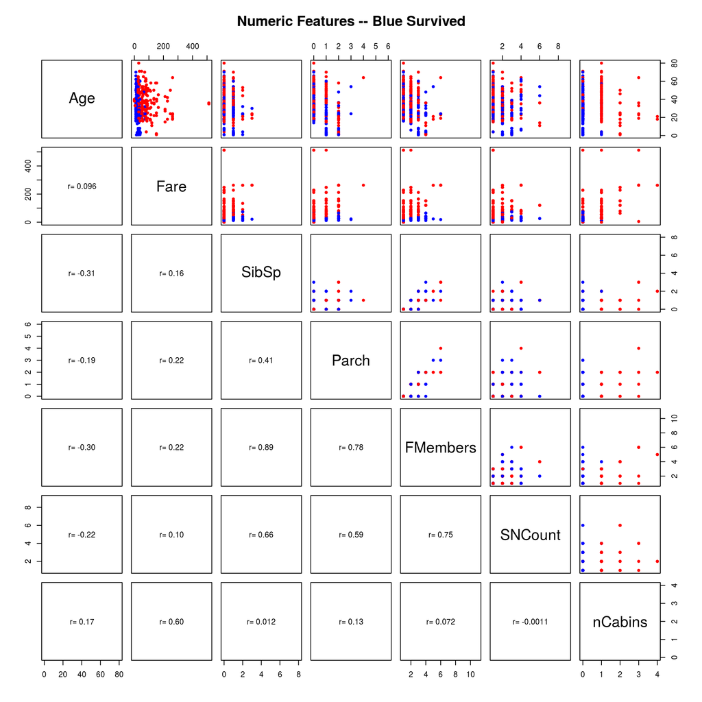

```r
pairs(
  train[, .(Age, Fare, SibSp, Parch, FMembers, SNCount, nCabins)],
  col = pal[train$Survived],
  pch = 20,
  main = "Numeric Features -- Blue Survived",
  lower.panel = panel.cor
)
```

## 4.2 Age

Let’s see if the age has a substantial effect on survival chances. I rather use densities here to compare distributions with different counts.

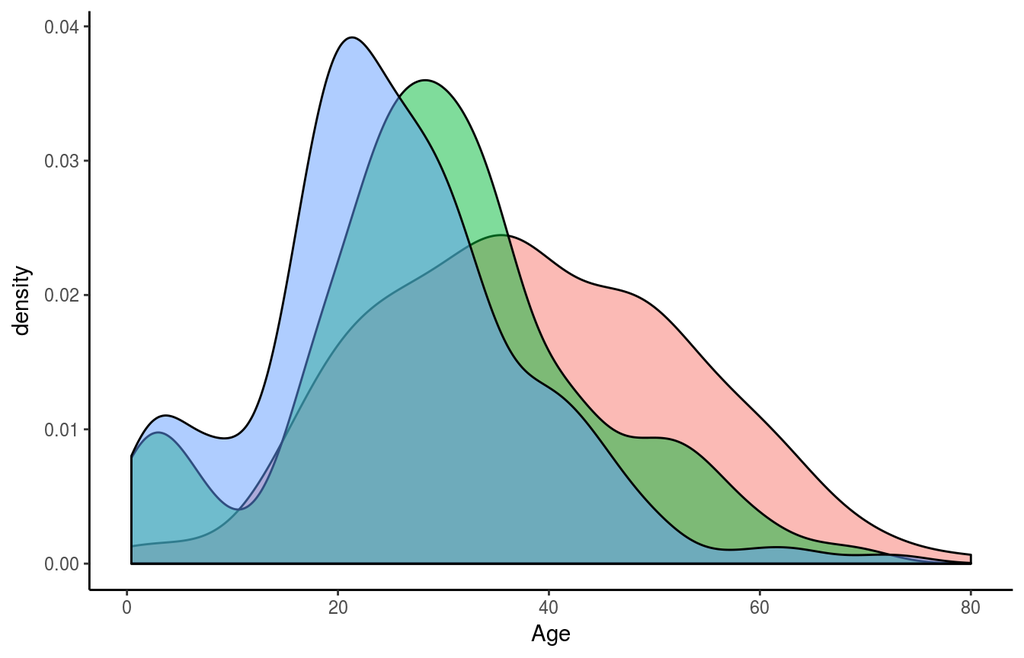

```r
ggplot(train) +
  geom_density(aes(x = Age, fill = Survived), alpha = .5) +
  theme_classic() +
  theme(legend.position = "none")
```

But let’s see the correlation for the binary feature *isChild*.

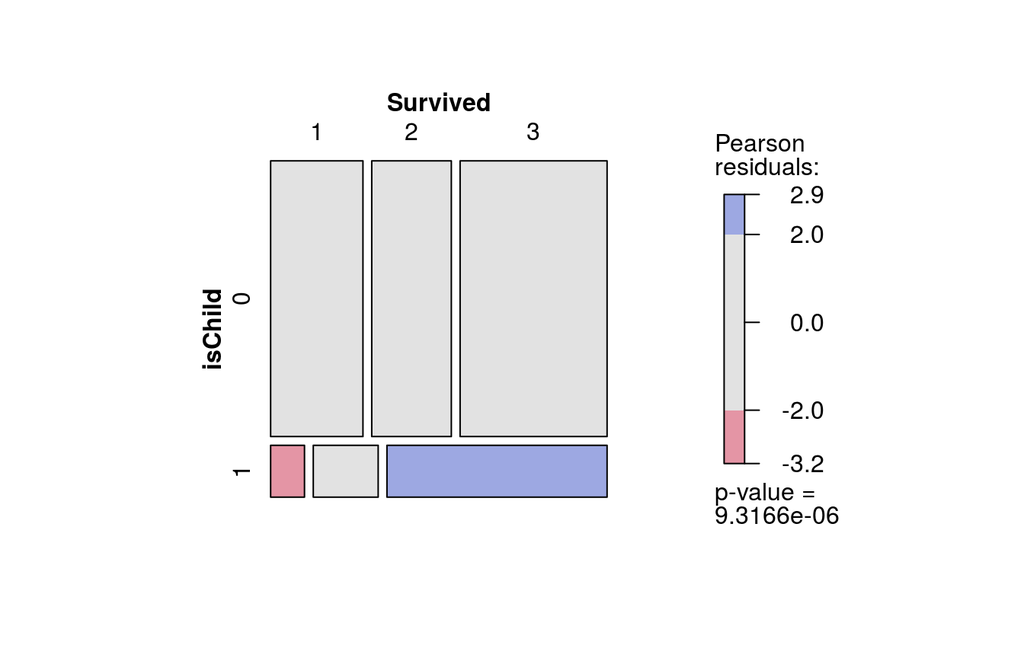

```r
mosaic(table(train[, .(isChild, Survived)],
             dnn = c("isChild", "Survived")), shade = TRUE)
```

There is a correlation, but not as strong as expected. Maybe 18 is the wrong threshold.

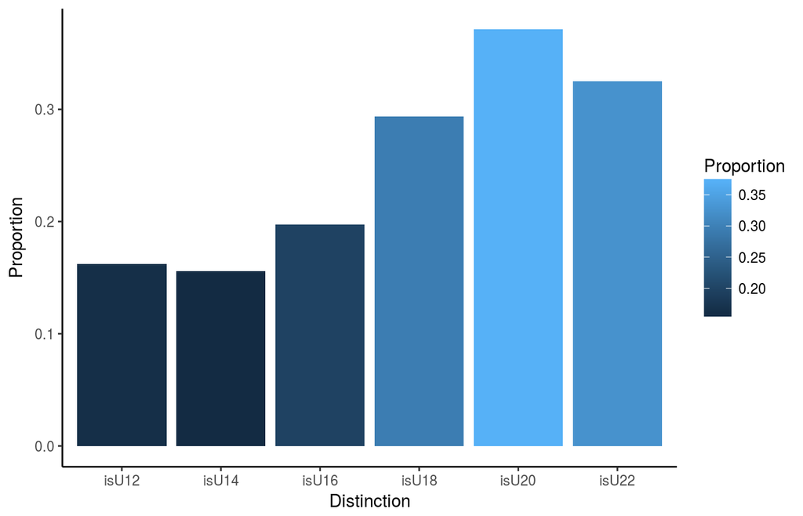

```r
dt <- train[!is.na(train$Age),
            .(isU12 = Age < 12, isU14 = Age < 14,
              isU16 = Age < 16, isU18 = Age < 18,
              isU20 = Age < 20, isU22 = Age < 22,
              Survived)]
dt <- dt[,
   .(isU12 = sum(isU12) / length(isU12), isU14 = sum(isU14) / length(isU14),
     isU16 = sum(isU16) / length(isU16), isU18 = sum(isU18) / length(isU18),
     isU20 = sum(isU20) / length(isU20), isU22 = sum(isU22) / length(isU22)),
   by = Survived]
dt <- melt(dt, measure.vars = 2:7, variable.name = "Distinction",
           value.name = "People")
f <- function(x) { x[2] / x[1] }
dt <- dt[, .(Proportion = f(People)), by = Distinction]
ggplot(dt, aes(x = Distinction, y = Proportion, fill = Proportion)) +
  geom_bar(position = "dodge", stat = "identity") +
  theme_classic()
```

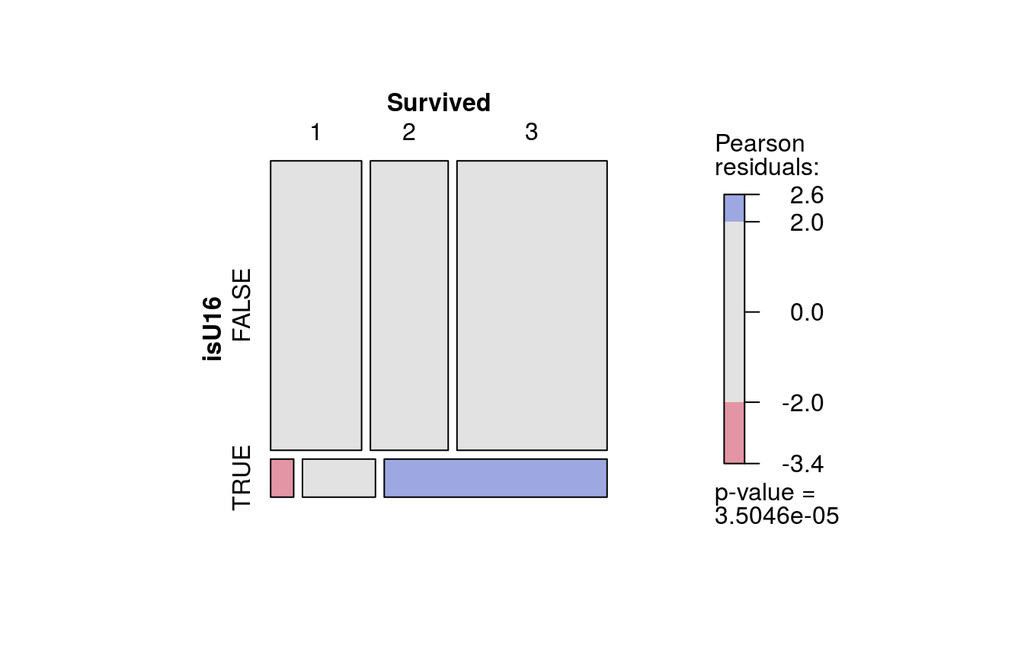

```r
train$isU16 <- train$Age < 16
mosaic(table(train[, .(isU16, Survived)],
             dnn = c("isU16", "Survived")), shade = TRUE)
```

## 4.3 SibSp

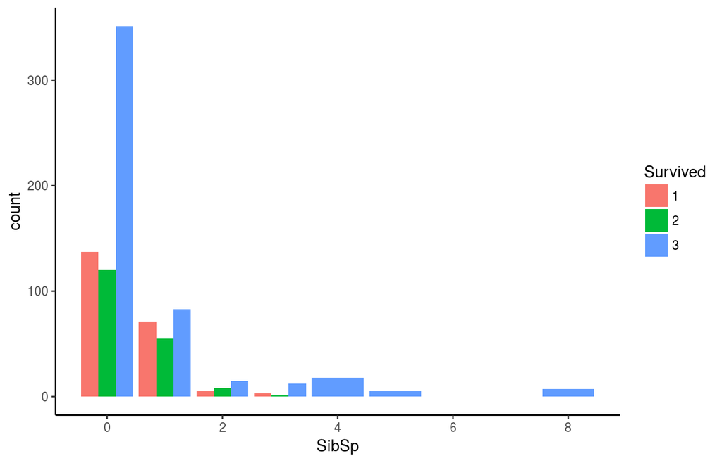

```r
ggplot(train, aes(x = SibSp, fill = Survived)) +
  geom_bar(position = "dodge") +
  theme_classic()
```

There seems to be a trend change for 1 sibling/spouse. These are the only ones with more survivors. A linear discriminant analysis would not be able to capture this. I have to use dummy variables for this.

## 4.4 Parch

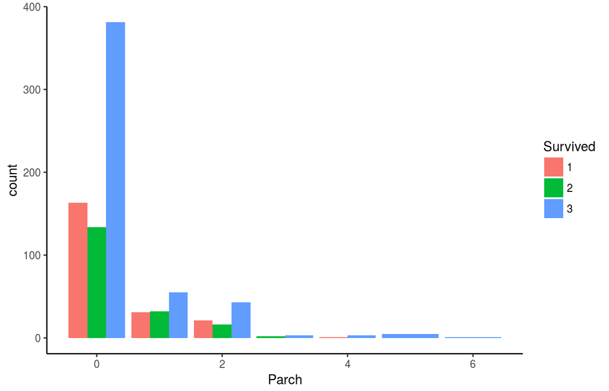

```r
ggplot(train, aes(x = Parch, fill = Survived)) +
  geom_bar(position = "dodge") +
  theme_classic()
```

They look very similar, which is not surprising. They were correlated.

## 4.5 FMembers

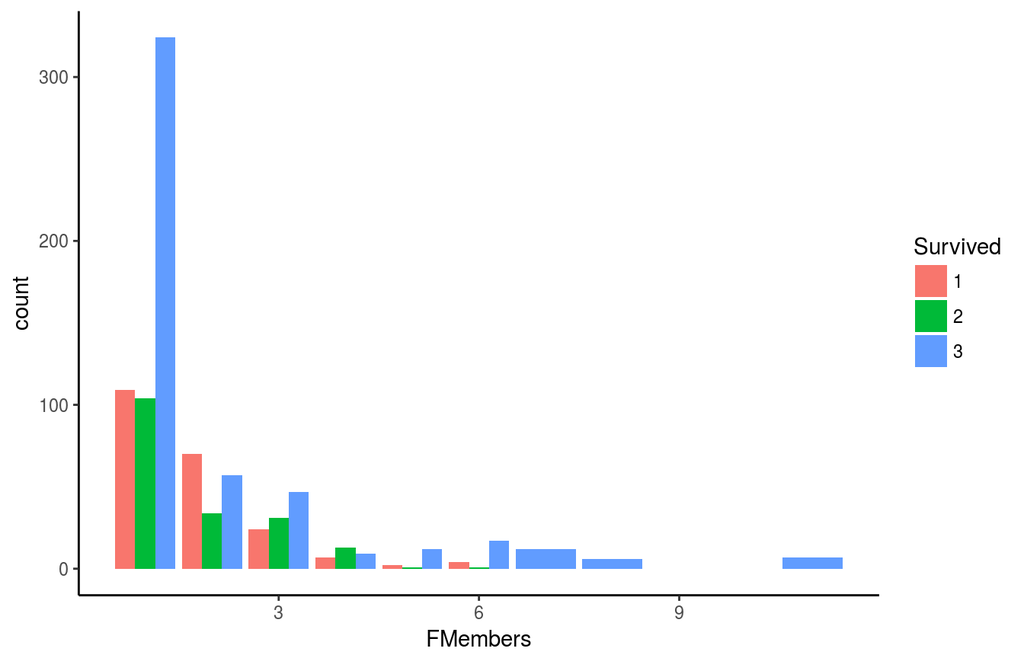

```r
ggplot(train, aes(x = FMembers, fill = Survived)) +
  geom_bar(position = "dodge") +
  theme_classic()
```

I think here the trend is clearest (compared to *SibSp* and *Parch*). I think about replacing these two features. *FMembers* of 2, 3, and 4 seem to be important.

## 4.6 SNCount

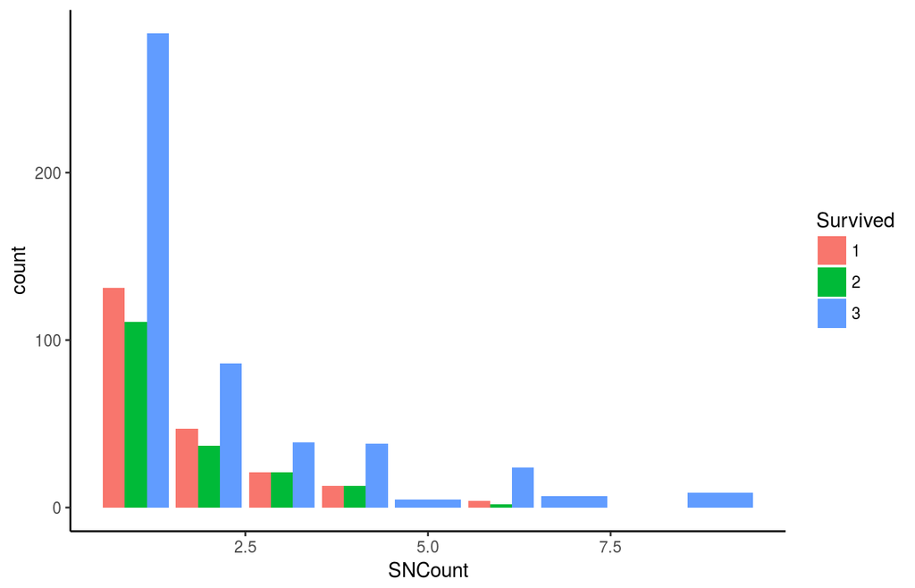

```r
ggplot(train, aes(x = SNCount, fill = Survived)) +
  geom_bar(position = "dodge") +
  theme_classic()
```

Similar to *SibSp* and *Parch*. They were also correlated.

## 4.7 Fare

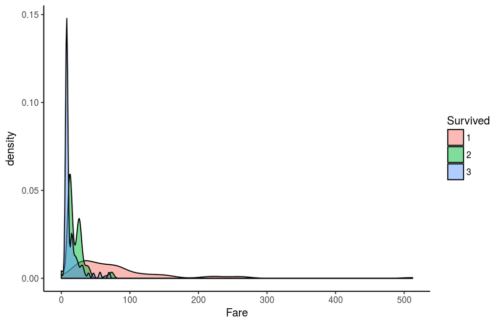

```r
ggplot(train) +
  geom_density(aes(x = Fare, fill = Survived), alpha = .5) +
  theme_classic()
```

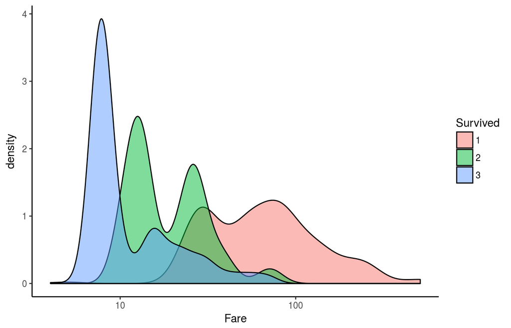

```r
ggplot(train) +
  geom_density(aes(x = Fare, fill = Survived), alpha = .5) +
  scale_x_continuous(trans = "log10") +
  theme_classic()
```

## 4.8 Pclass

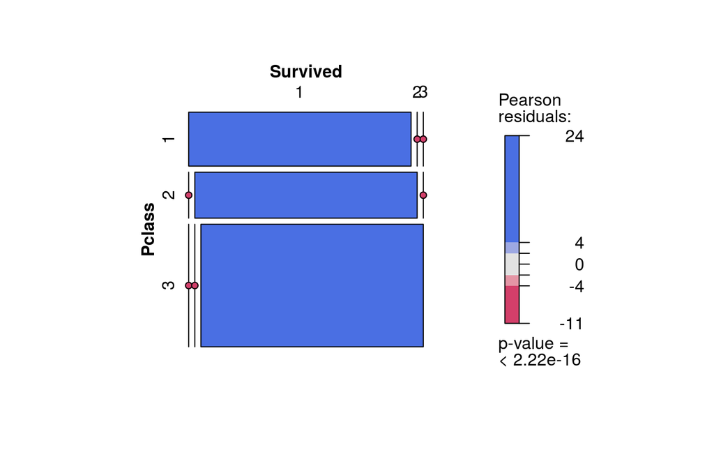

```r
mosaic(table(train[, .(Pclass, Survived)],
             dnn = c("Pclass", "Survived")), shade = TRUE)
```

This feature is useful. Higher classes had better survial chances. This should be correlated to *Fare*.

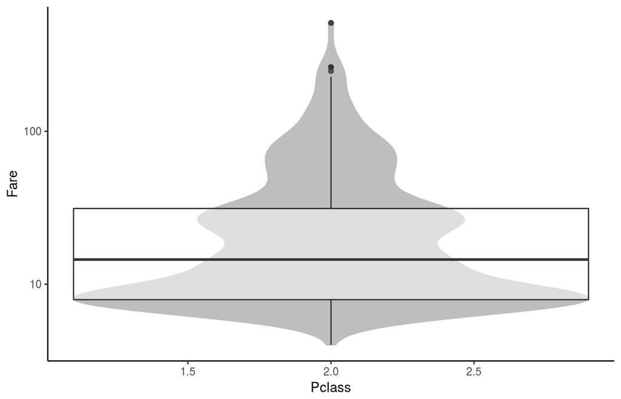

```r
ggplot(train, aes(x = Pclass, y = Fare)) +
  geom_violin(fill = "gray", color = "gray") +
  geom_boxplot(varwidth = TRUE, alpha = .5) +
  scale_y_continuous(trans = "log10") +
  theme_classic()
```

Yes it is.

## 4.9 Ticket Text

```r
table(train$Survived, train$TicketText)
```

```
##
##           A  AS   C  CA CASOTON  FA  FC FCC LINE  PC  PP PPP  SC SCA SCAH
##   1 152   0   0   0   0       0   0   1   0    0  60   0   0   0   0    0
##   2 127   0   0   0  19       1   0   0   5    0   0   0   2   1   0    2
##   3 382  28   1   5  22       0   1   0   0    4   0   3   0   0   1    0
##
##     SCAHBASLE SCOW SCPARIS SOC SOP SOPP SOTONO SOTONOQ  SP STONO SWPP  WC
##   1         0    0       0   0   0    0      0       0   0     0    0   0
##   2         1    1      11   6   1    2      0       0   0     0    2   3
##   3         0    0       0   0   0    1      2      15   1    18    0   7
##
##     WEP
##   1   3
##   2   0
##   3   0
```

Some of these labels don’t appear very often. Maybe I should reduce them to the ones with at least 10 counts.

```r
tab <- table(train$TicketText)
(tab <- tab[tab > 10])
```

```
##
##               A      CA      PC SCPARIS SOTONOQ   STONO
##     661      28      41      60      11      15      18
```

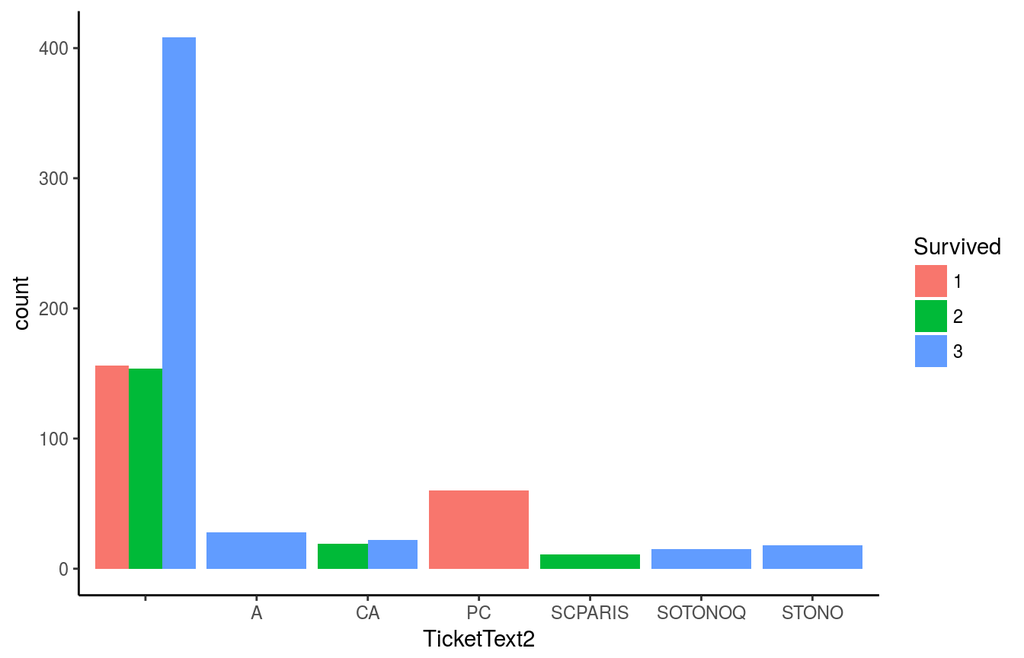

```r
txt <-names(tab[-1])
txt <- vapply(
  train$TicketText,
  function(i) {
    idx <- which(txt %in% i)
    if (length(idx) < 1) "" else txt[idx]
  },
  character(1)
)
train$TicketText2 <- txt
ggplot(train, aes(x = TicketText2, fill = Survived)) +
  geom_bar(position = "dodge") +
  theme_classic()
```

The *PC* label in the ticket might be a survival indicator. I should set up a dummy variable for this.

```r
train$TicketIsPC <- train$TicketText2 == "PC"
```

Does *PC* stand for the embarkment port?

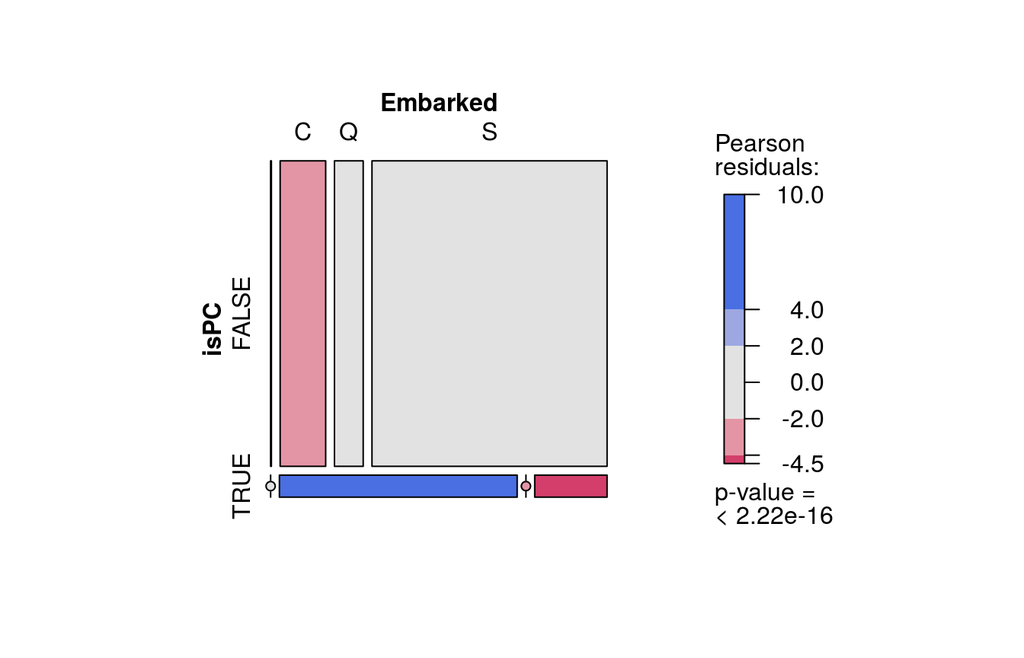

```r
mosaic(table(train[, .(TicketIsPC, Embarked)],
             dnn = c("isPC", "Embarked")), shade = TRUE)
```

Not really, people from Cherbourg and people form Southampton have it.

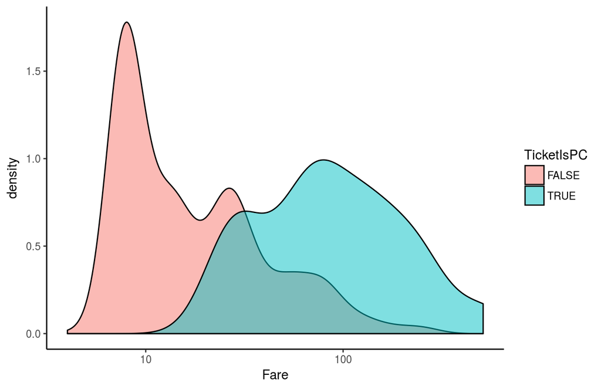

```r
ggplot(train) +
  geom_density(aes(x = Fare, fill = TicketIsPC), alpha = .5) +
  scale_x_continuous(trans = "log10") +
  theme_classic()
```

Tickets with *PC* were more expensive overall.

So, I just compared *TicketIsPC* to the other features but did not see any eye opening structure. I will save the plots and leave it like this.

## 4.10 Deck

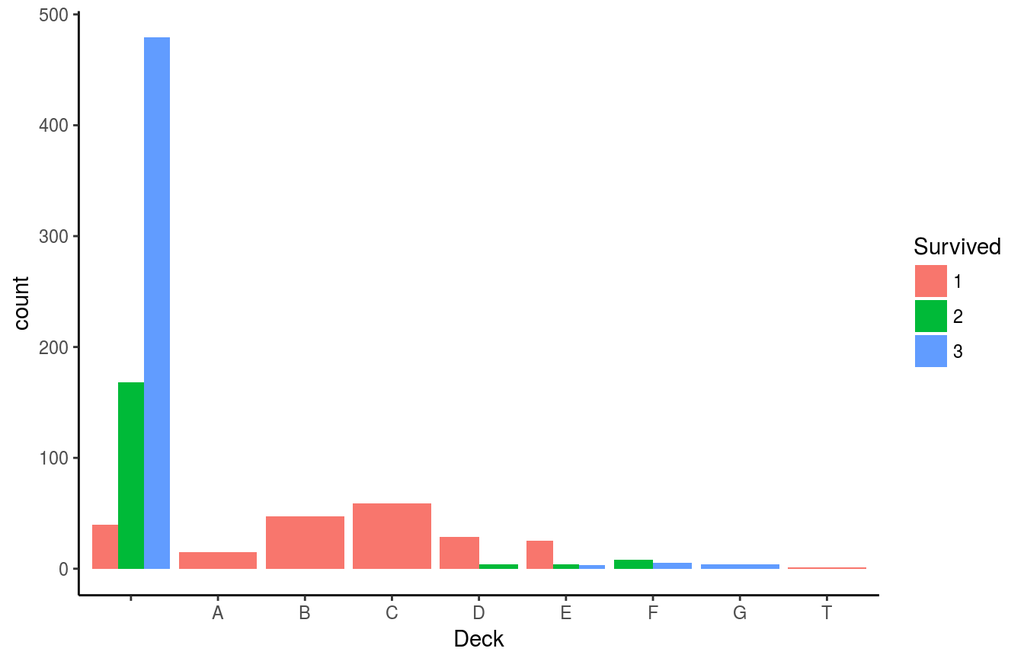

```r
ggplot(train, aes(x = Deck, fill = Survived)) +
  geom_bar(position = "dodge") +
  theme_classic()
```

Except for *A* it looks as expected. I would have thought the deck *A* people had the highest survival chances. Aren’t these the one who also payed most?

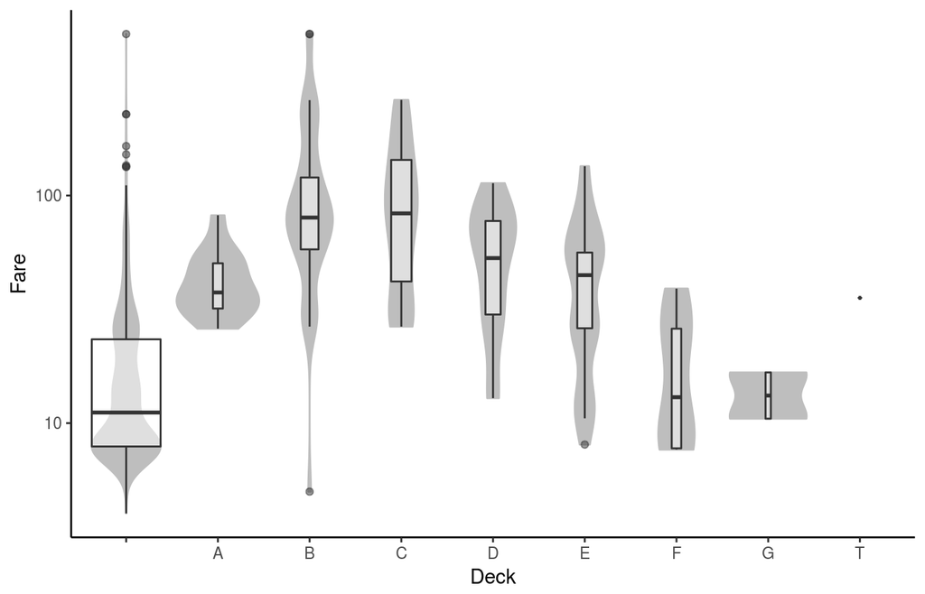

```r
ggplot(train, aes(x = Deck, y = Fare)) +
  geom_violin(fill = "gray", color = "gray") +
  geom_boxplot(varwidth = TRUE, alpha = .5) +
  scale_y_continuous(trans = "log10") +
  theme_classic()
```

Apparently not. The ticket fare to deck trend resembles the survival to deck trend. B to D payed the most, and they also had the highest survival rate.

## 4.11 Cabins

Let’s see the correlation of survival chances and cabin numbers on the ticket.

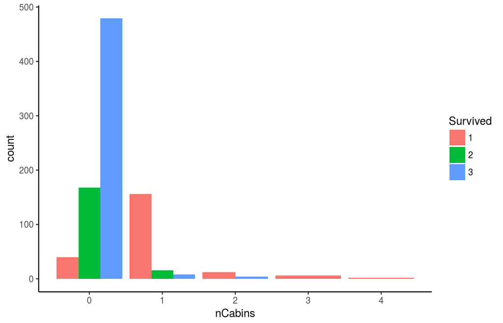

```r
ggplot(train, aes(x = nCabins, fill = Survived)) +
  geom_bar(position = "dodge") +
  theme_classic()
```

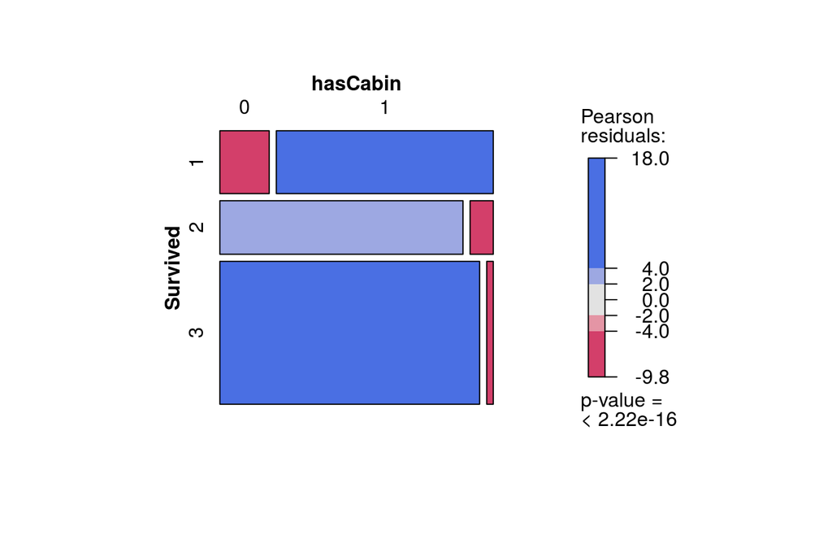

```r
mosaic(table(train[, .(Survived, hasCabin)],
             dnn = c("Survived", "hasCabin")), shade = TRUE)
```

So, having no cabin number on the ticket is a bad omen.

## 4.12 Embarked

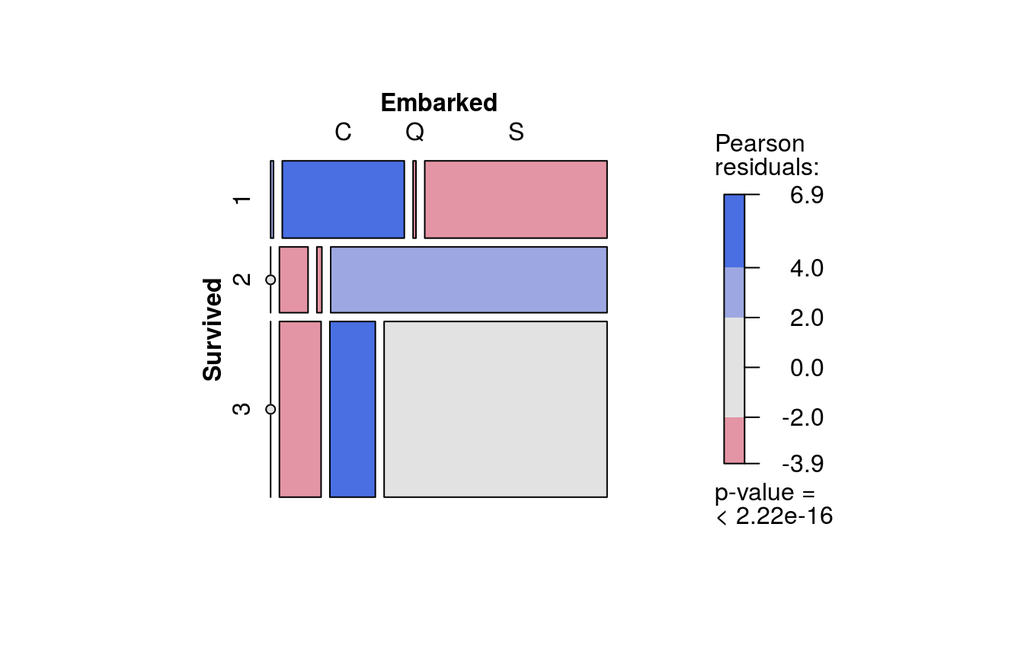

```r
mosaic(table(train$Survived, train$Embarked,
             dnn = c("Survived", "Embarked")), shade = TRUE)
```

Interestingly, people embarking from Cherbourg had higher survival chances. Is this related to one of the other features that we already found to correlate with survival?

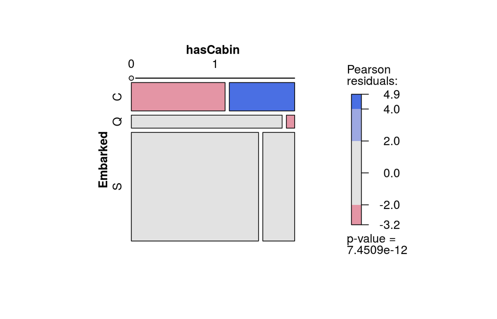

```r
mosaic(table(train[, .(Embarked, hasCabin)],
             dnn = c("Embarked", "hasCabin")), shade = TRUE)
```

Indeed, by far more people embarking form Cherbourg did have a cabin. And as indicated above having a cabin seemed to increase survival chances. Let’s make a new feature for this.

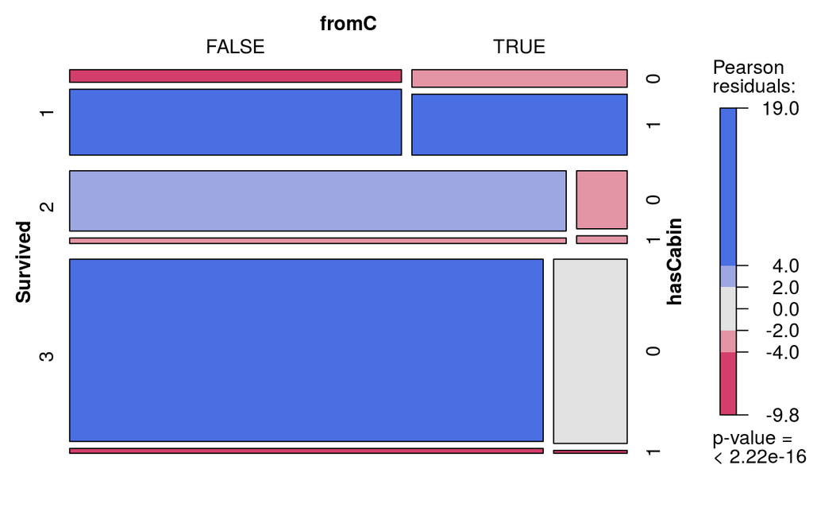

```r
train$fromC <- train$Embarked == "C"
mosaic(table(train[, .(Survived, fromC, hasCabin)],
             dnn = c("Survived", "fromC", "hasCabin")), shade = TRUE)
```

## 4.13 Title

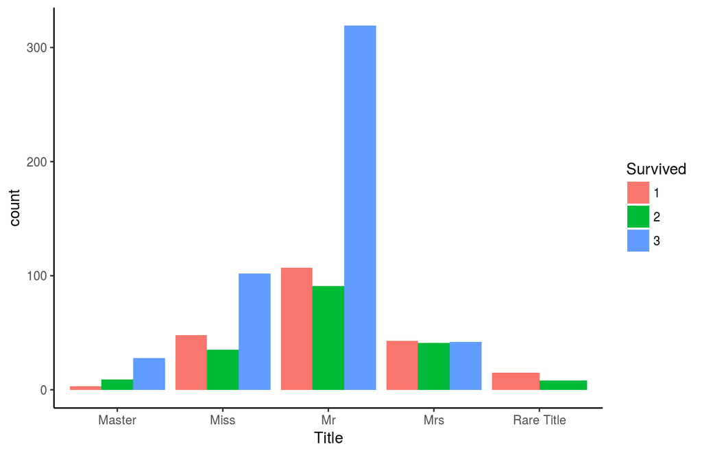

```r
ggplot(train, aes(x = Title, fill = Survived)) +
  geom_bar(position = "dodge") +
  theme_classic()
```